# Self-reported expressibility predicts communicative success: Open dataset, validation, and simulation

# 8 Hypothesis 4: Guessability vs. modality

*Guessability will differ by modality; the order from highest to lowest will be: combined > gesture > vocalization.*

## 8.1 Guess binary

Preregistered model: `guessability_match ~ modality + (1 | dyad/participant) + (1 | concept), family = bernoulli(link='logit')`

```r
mdl_H4_binary <- readRDS(paste0(models, "mdl_H4_binary.rds"))
```

Calculate R².

```
##     Estimate   Est.Error      Q2.5     Q97.5
## R2 0.3119471 0.006233031 0.2994827 0.3240461
```

R² is 0.3119471 suggesting that 31.1947143% of the variance in the outcome variable is explained by the model.

**Diagnostic plots**:

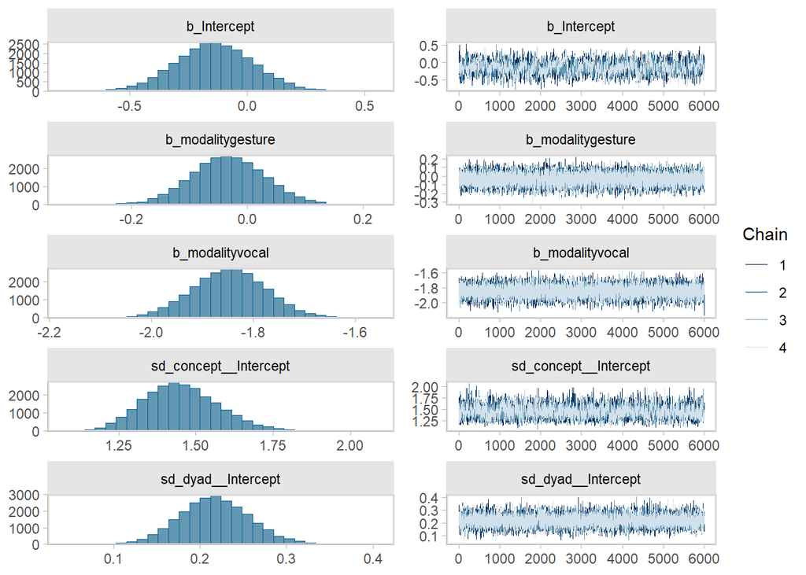

```r
plot(mdl_H4_binary)
```

**Convergence**: All convergence diagnostics are excellent (Rhat = 1.00).

```r
summary(mdl_H4_binary)
```

```
##  Family: bernoulli
##   Links: mu = logit
## Formula: guess_binary ~ modality + (1 | dyad) + (1 | concept)
##    Data: df (Number of observations: 8989)
##   Draws: 4 chains, each with iter = 10000; warmup = 4000; thin = 1;
##          total post-warmup draws = 24000
##
## Multilevel Hyperparameters:
## ~concept (Number of levels: 84)
##               Estimate Est.Error l-95% CI u-95% CI Rhat Bulk_ESS Tail_ESS
## sd(Intercept)     1.45      0.12     1.23     1.72 1.00     3174     6049
##
## ~dyad (Number of levels: 71)
##               Estimate Est.Error l-95% CI u-95% CI Rhat Bulk_ESS Tail_ESS
## sd(Intercept)     0.22      0.04     0.14     0.30 1.00    10308    12279
##
## Regression Coefficients:
##                 Estimate Est.Error l-95% CI u-95% CI Rhat Bulk_ESS Tail_ESS
## Intercept          -0.14      0.17    -0.47     0.19 1.00     1340     2945
## modalitygesture    -0.03      0.06    -0.16     0.09 1.00    29895    19530
## modalityvocal      -1.85      0.07    -1.99    -1.71 1.00    28851    19306
##
## Draws were sampled using sampling(NUTS). For each parameter, Bulk_ESS
## and Tail_ESS are effective sample size measures, and Rhat is the potential
## scale reduction factor on split chains (at convergence, Rhat = 1).
```

```
## No divergences to plot.
```

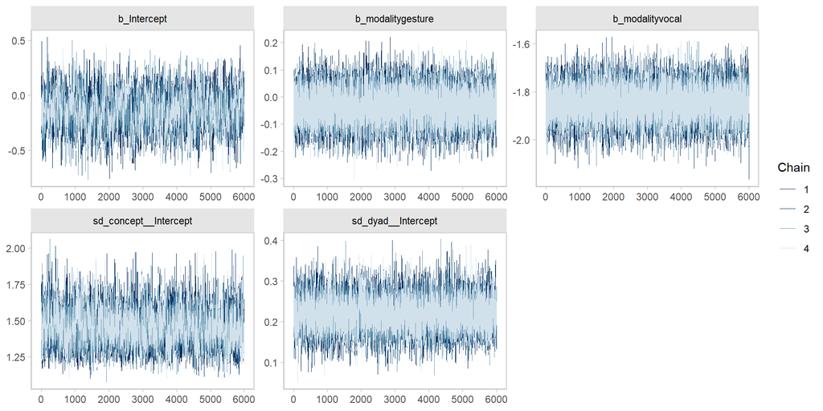

**Figure 76.** Trace of the fitting process. Figure generated using [`R`](https://www.r-project.org/) version 4.4.1 (2024-06-14 ucrt)

```r
mcmc_plot(mdl_H4_binary, type="trace");
```

**Posterior predictive checks**: Looking good.

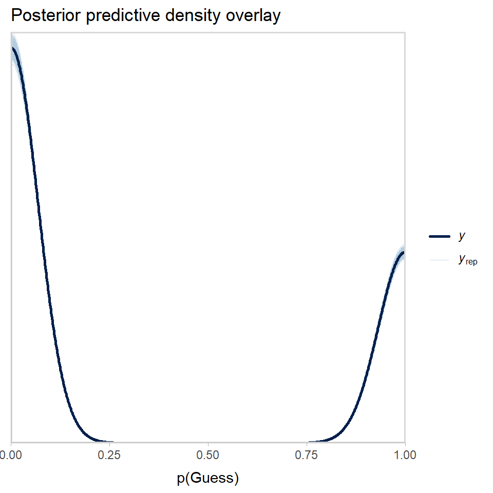

**Figure 77.** Posterior predictive density overlay for n=500 draws. Figure generated using [`R`](https://www.r-project.org/) version 4.4.1 (2024-06-14 ucrt)

```r
pp_check(mdl_H4_binary, ndraws=500) + xlab('p(Guess)') + ggtitle('Posterior predictive density overlay');
```

```
## Using all posterior draws for ppc type 'stat' by default.
## Using all posterior draws for ppc type 'stat' by default.
## Using all posterior draws for ppc type 'stat' by default.
```

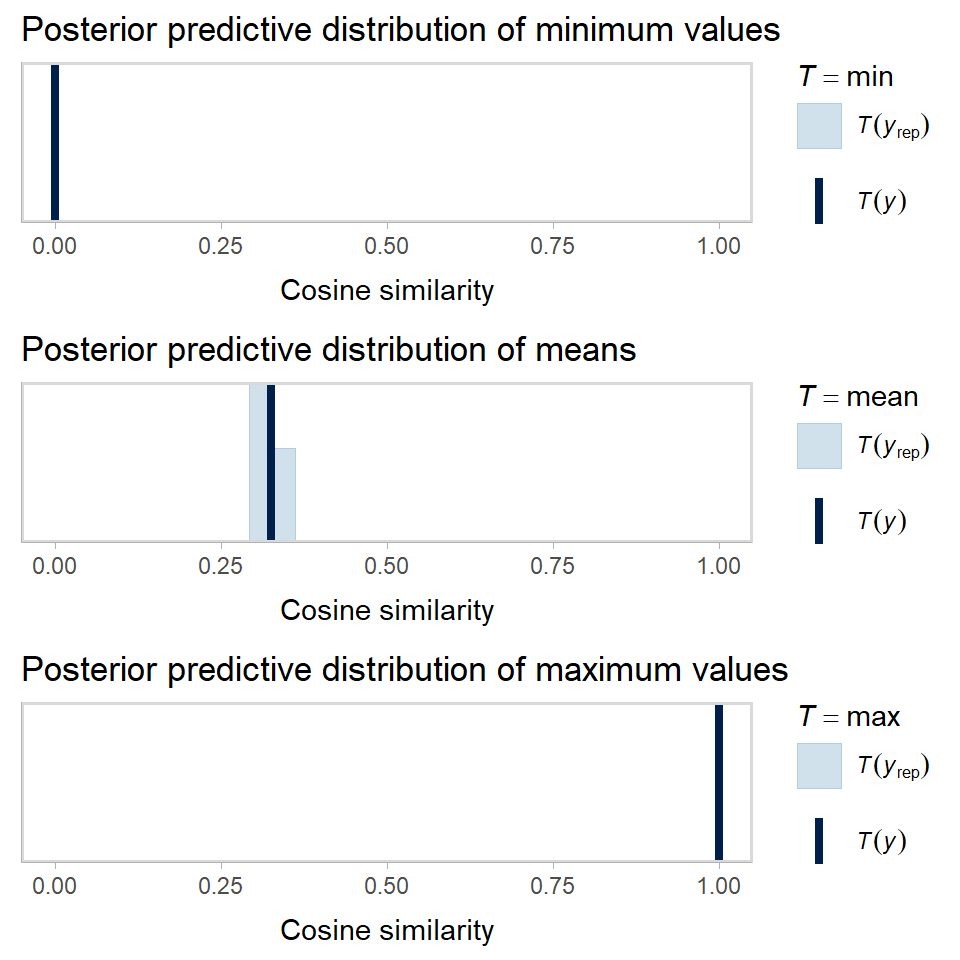

**Figure 78.** Posterior predictive distribution. Figure generated using [`R`](https://www.r-project.org/) version 4.4.1 (2024-06-14 ucrt)

```r
grid.arrange(pp_check(mdl_H4_binary, type='stat', sta ='min') + xlab('Cosine similarity') + ggtitle('Posterior predictive distribution of minimum values') + xlim(0,1),
             pp_check(mdl_H4_binary, type='stat', stat='mean') + xlab('Cosine similarity') + ggtitle('Posterior predictive distribution of means') + xlim(0,1),
             pp_check(mdl_H4_binary, type='stat', stat='max') + xlab('Cosine similarity') + ggtitle('Posterior predictive distribution of maximum values') + xlim(0,1),
             ncol=1);
```

**Fixed effects**:

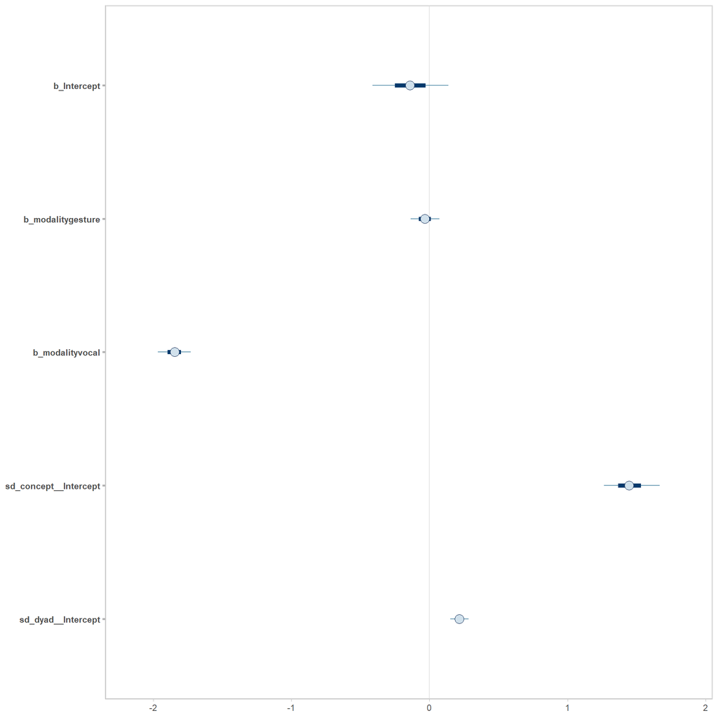

**Figure 79.** Fixed effects’ posterior distributions. Figure generated using [`R`](https://www.r-project.org/) version 4.4.1 (2024-06-14 ucrt)

```r
mcmc_plot(mdl_H4_binary);
```

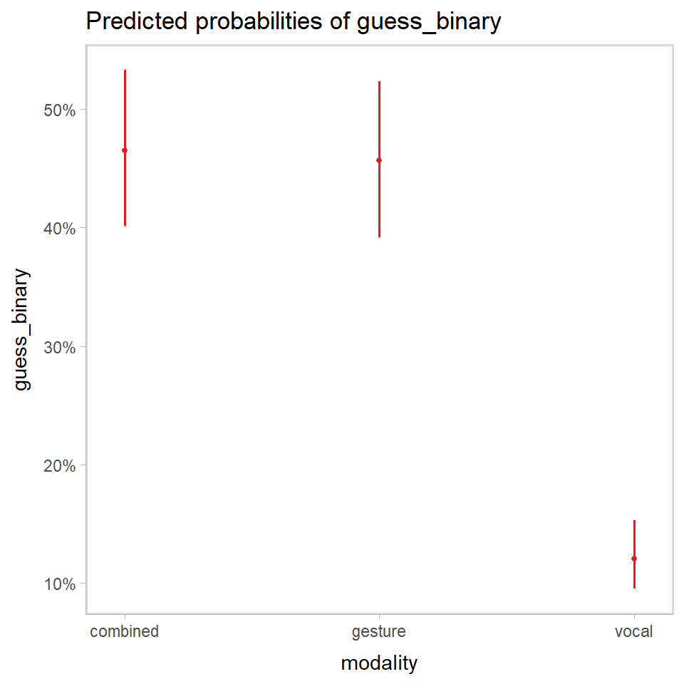

**Figure 80.** Fixed effects. Figure generated using [`R`](https://www.r-project.org/) version 4.4.1 (2024-06-14 ucrt)

```r
plot_model(mdl_H4_binary, type="emm", terms=c("modality"));
```

```r
# because of the logit link, it needs to be backtransformed
emmeans(mdl_H4_binary, ~ modality)
```

```
##  modality emmean lower.HPD upper.HPD
##  combined -0.141    -0.465     0.187
##  gesture  -0.174    -0.495     0.163
##  vocal    -1.988    -2.320    -1.655
##
## Point estimate displayed: median
## Results are given on the logit (not the response) scale.
## HPD interval probability: 0.95
```

```r
emmeans(mdl_H4_binary, ~ modality, type = "response")
```

```
##  modality response lower.HPD upper.HPD
##  combined    0.465    0.3857     0.547
##  gesture     0.457    0.3787     0.541
##  vocal       0.120    0.0873     0.158
##
## Point estimate displayed: median
## Results are back-transformed from the logit scale
## HPD interval probability: 0.95
```

```r
pairs(emmeans(mdl_H4_binary, ~ modality))
```

```
##  contrast           estimate lower.HPD upper.HPD
##  combined - gesture   0.0335   -0.0938     0.157
##  combined - vocal     1.8465    1.7053     1.989
##  gesture - vocal      1.8138    1.6721     1.957
##
## Point estimate displayed: median
## Results are given on the log odds ratio (not the response) scale.
## HPD interval probability: 0.95
```

```r
pairs(emmeans(mdl_H4_binary, ~ modality, type = "response"))
```

```
##  contrast           odds.ratio lower.HPD upper.HPD
##  combined / gesture       1.03     0.904      1.16
##  combined / vocal         6.34     5.472      7.27
##  gesture / vocal          6.13     5.296      7.05
##
## Point estimate displayed: median
## Results are back-transformed from the log odds ratio scale
## HPD interval probability: 0.95
```

```r
bayestestR::hdi(mdl_H4_binary, ci=0.95)
```

|  | Parameter | CI | CI_low | CI_high | Effects | Component |
| --- | --- | --- | --- | --- | --- | --- |
| 1 | b_Intercept | 0.95 | -0.4654492 | 0.18727507 | fixed | conditional |
| 2 | b_modalitygesture | 0.95 | -0.1572012 | 0.09383298 | fixed | conditional |
| 3 | b_modalityvocal | 0.95 | -1.9893456 | -1.70532958 | fixed | conditional |

```r
hypothesis(mdl_H4_binary, c("modalitygesture < 0",
                            "modalityvocal < 0"
                            ))
```

```
## Hypothesis Tests for class b:
##              Hypothesis Estimate Est.Error CI.Lower CI.Upper Evid.Ratio
## 1 (modalitygesture) < 0    -0.03      0.06    -0.14     0.07       2.33
## 2   (modalityvocal) < 0    -1.85      0.07    -1.97    -1.73        Inf
##   Post.Prob Star
## 1       0.7
## 2       1.0    *
## ---
## 'CI': 90%-CI for one-sided and 95%-CI for two-sided hypotheses.
## '*': For one-sided hypotheses, the posterior probability exceeds 95%;
## for two-sided hypotheses, the value tested against lies outside the 95%-CI.
## Posterior probabilities of point hypotheses assume equal prior probabilities.
```

```r
hypothesis(mdl_H4_binary,
  c(# combined better than gesture
    "inv_logit_scaled(Intercept) > inv_logit_scaled(Intercept + modalitygesture)",
    # combined better than vocal
    "inv_logit_scaled(Intercept) > inv_logit_scaled(Intercept + modalityvocal)",
    # gesture better than vocal
    "inv_logit_scaled(Intercept + modalitygesture) > inv_logit_scaled(Intercept + modalityvocal)"
  ))
```

```
## Hypothesis Tests for class b:
##                 Hypothesis Estimate Est.Error CI.Lower CI.Upper Evid.Ratio
## 1 (inv_logit_scaled... > 0     0.01      0.02    -0.02     0.03       2.33
## 2 (inv_logit_scaled... > 0     0.34      0.03     0.30     0.39        Inf
## 3 (inv_logit_scaled... > 0     0.34      0.03     0.29     0.38        Inf
##   Post.Prob Star
## 1       0.7
## 2       1.0    *
## 3       1.0    *
## ---
## 'CI': 90%-CI for one-sided and 95%-CI for two-sided hypotheses.
## '*': For one-sided hypotheses, the posterior probability exceeds 95%;
## for two-sided hypotheses, the value tested against lies outside the 95%-CI.
## Posterior probabilities of point hypotheses assume equal prior probabilities.
```

```r
draws <- as_draws_df(mdl_H4_binary) %>%  # or as_draws()
  mutate(
    p_combined = plogis(b_Intercept),
    p_gesture  = plogis(b_Intercept + `b_modalitygesture`),
    p_vocal    = plogis(b_Intercept + `b_modalityvocal`)
  )

draws_summary <- draws %>%
  summarise(
    # Combined
    mean_combined = mean(p_combined),
    ci_combined   = ci(p_combined, ci=0.95, method="ETI"),
    # Gesture
    mean_gesture  = mean(p_gesture),
    ci_gesture    = ci(p_gesture, ci=0.95, method="ETI"),
    # Vocal
    mean_vocal    = mean(p_vocal),
    ci_vocal      = ci(p_vocal, ci=0.95, method="ETI")
  )
# Probability for combined with 95% ETI:
p_comb_mean <- mean(draws$p_combined)
p_comb_ci   <- ci(draws$p_combined, ci=0.95, method="ETI")
```

**Intercept**: The intercept is -0.14 95%CI [-0.47, 0.19] on the log-odds ratio (LOR) scale. When we convert this value using the inverse-logit transformation, it corresponds to an overall predicted probability of a correct guess (when **combined** is the reference modality) of 46.5% 95%CI [38.5%, 54.7%].

**Modality (gesture)**: The effect of *gesture* is -0.03 95%CI [-0.16, 0.09] on the log-odds scale. In other words, when we switch from **combined** to **gesture**, the predicted probability of a correct guess changes from about 46.5% 95%CI [38.5%, 54.7%] (**combined**) to 45.7% 95%CI [37.7%, 54.0%] (**gesture**). Since the estimate is close to zero (and its 95% CI straddles zero), we see that **combined** and **gesture** yield similar guessability probabilities.

**Modality (vocal)**: The effect of *vocal* is -1.85 95%CI [-1.99, -1.71] on the log-odds scale. Switching from **combined** to **vocal** decreases the probability of a correct guess from about 46.5% 95%CI [38.5%, 54.7%] (**combined**) to 12.2% 95%CI [8.9%, 16.0%] (**vocal**). This large negative effect indicates that **vocal** productions are much less likely to be guessed correctly than **combined**.

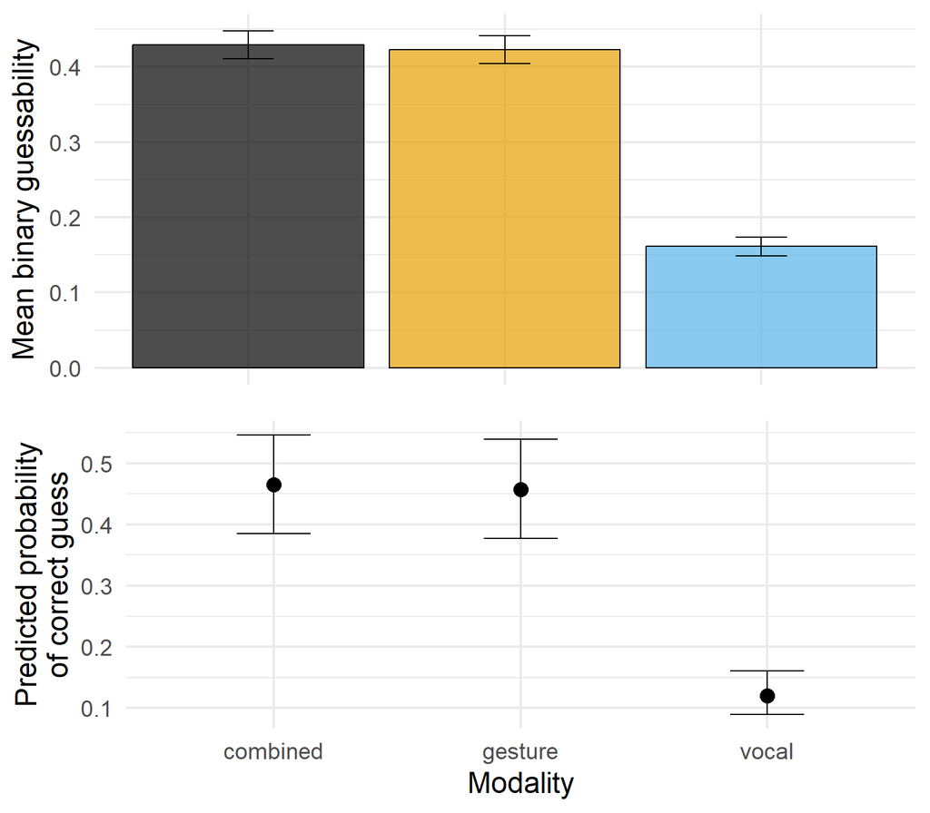

**Figure 81.** Top: Raw mean binary guessability by modality. Bottom: Model-predicted probability of a correct guess by modality. The plot shows the median predicted probability along with uncertainty bands. Figure generated using [`R`](https://www.r-project.org/) version 4.4.1 (2024-06-14 ucrt)

```r
# Panel 1: Observed distribution of modality by guess outcome
p_obs <- ggplot(df, aes(x = modality, y = guess_binary, fill = modality)) +
  stat_summary(fun = "mean", geom = "bar", color = "black", alpha = 0.7) +  # Calculate mean for guess_binary (performance)
  stat_summary(fun.data = "mean_cl_normal", geom = "errorbar", width = 0.2) +  # Add error bars (95% CI)
  labs(
    x = "Modality",
    y = "Mean binary guessability",
  ) +
  scale_fill_manual(values = c("combined" = colorBlindBlack8[1], "gesture" = colorBlindBlack8[2], "vocal" = colorBlindBlack8[3])) +  # Customize colors
  guides(fill = "none") +  # Remove the fill legend
  # scale_y_continuous(breaks = seq(0, 1, by = 0.05),
  #                    limits = c(0,1)) +
  theme_minimal(base_size = 18) +
    theme(
      #text = element_text(size = 14),  # Increase text size for readability
      axis.text.x = element_blank(),
      axis.title.x = element_blank(),
      axis.title.y = element_text(vjust = 1.5)   # Adjust y-axis title position
    )

# Panel 2: Conditional effects of exp_part on predicted probability
ce_exp <- conditional_effects(mdl_H4_binary, effects = "modality")
p_pred <- plot(ce_exp, plot = FALSE)[[1]] +
  labs(x = "Modality", y = "Predicted probability\nof correct guess") +
  theme_minimal(base_size = 18)

# Arrange the two panels vertically using grid.arrange
grid.arrange(p_obs, p_pred, ncol = 1)
```

```r
#save
g <- arrangeGrob(p_obs, p_pred, ncol = 1)

ggsave(paste0(plots, "H4_binaryModel.png"), plot = g, width = 8, height = 8, dpi = 300)
```

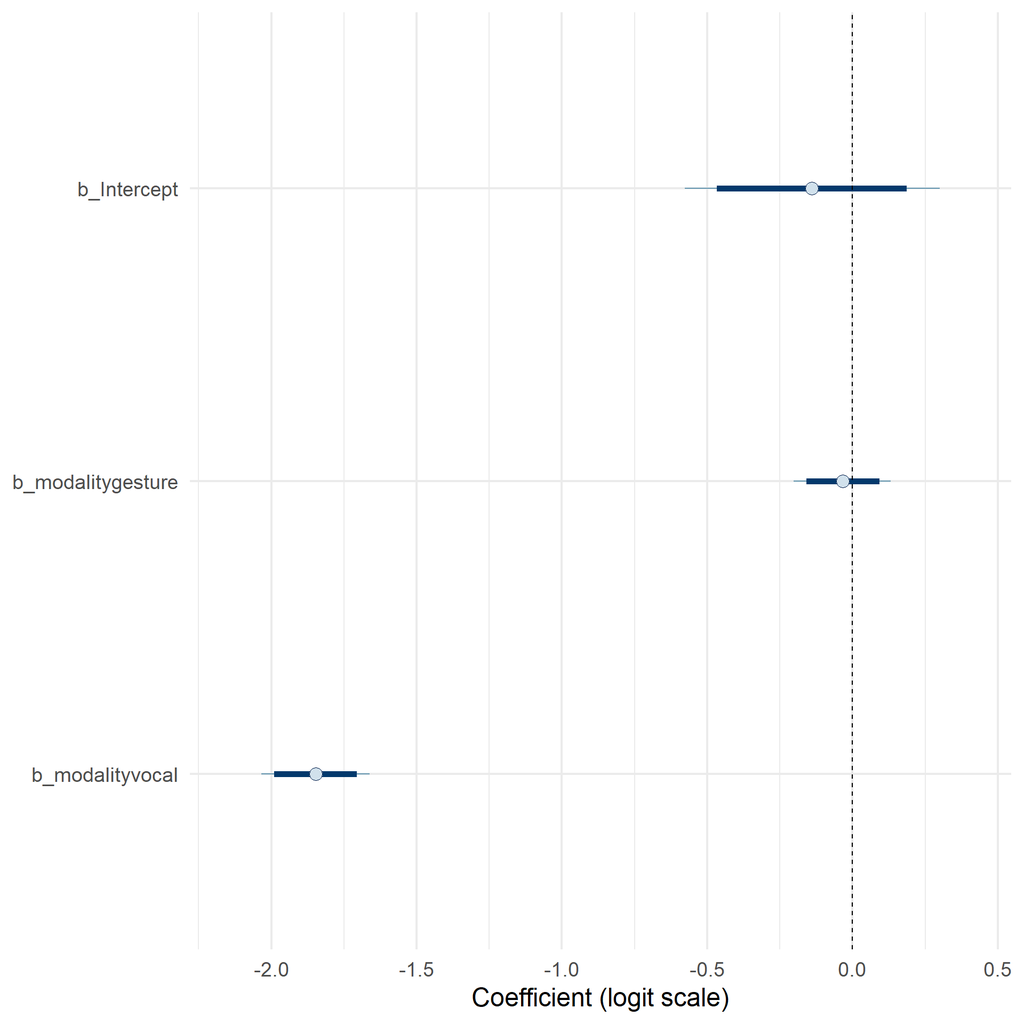

**Figure 82.** Posterior draws for the fixed effects. Figure generated using [`R`](https://www.r-project.org/) version 4.4.1 (2024-06-14 ucrt)

```r
# Extract posterior draws for the fixed effects
# For our binary model, the coefficients are on the logit scale.
posterior_fixed <- as.matrix(mdl_H4_binary, variable = c("b_Intercept", "b_modalitygesture", "b_modalityvocal"))

# Plot using mcmc_intervals; we add a dashed vertical line at 0 for reference.
mcmc_intervals(posterior_fixed, prob = 0.95, prob_outer = 0.99) +
  geom_vline(xintercept = 0, linetype = "dashed") +
  labs(
    x = "Coefficient (logit scale)"
  ) +
  theme_minimal(base_size = 18)
```